# FigureYa45 iCluster的教程答疑

小丫画图出品

10/14/2018

微信ID: epigenomics E-mail: epigenomics@rainbow-genome.com

本代码作者：徐洲更https://www.jianshu.com/u/9ea40b5f607a

小丫编辑校验

### 需求描述

iCluster分析过程答疑。

另外，需要输出分类和特征基因，用于画paper里的这种热图。

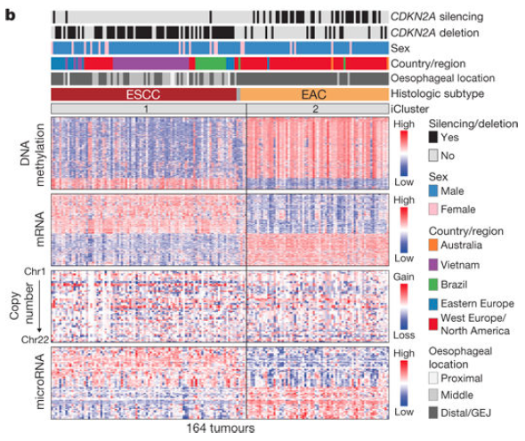

出自https://www.nature.com/articles/nature20805

可以用`FigureYa17已分类的heatmap`来画heatmap，从本代码输出的`output_clusterMembership.txt`中取一列分类，作为sample分组信息。例图iCluster的两类完全分开，为了达到这种效果，需要单独画1类和2类，然后拼在一起。

### 应用场景

使用iClusterPlus整合多种基因组数据。

肿瘤的分子复杂性体现在基因组、表观组、转录组和蛋白组等多种水平。

一种方法是单独对不同数据类型进行据类然后手动合并。而`iCluster`则是同时使用多种来源数据进行整合分析，用于识别肿瘤亚型。

`iCluster`在2009年开发，中间经历了很多次的开发升级，目前最新版是Bioconductor上的`iClusterPlus`

> iClusterPlus is developed for integrative clustering analysis of multi-type genomic data and is an enhanced version of iCluster proposed and developed by Shen, Olshen and Ladanyi (2009).

### 环境准备

#### 安装iClusterPlus

`iClusterPlus`需要通过`biocLite`安装，如果速度慢，将下面代码`#options(...)`中的`#`去掉，则会使用国内镜像.

CRAN镜像备选

- 国科大: https://mirrors.ustc.edu.cn/CRAN/
- 同济大学: https://mirrors.tongji.edu.cn/CRAN/
- 兰州大学: https://mirror.lzu.edu.cn/CRAN/

```r
#source("https://bioconductor.org/biocLite.R")
#options("repos"= c(CRAN="https://mirrors.tuna.tsinghua.edu.cn/CRAN/"))
#options(BioC_mirror="http://mirrors.ustc.edu.cn/bioc/")
if ( ! require(iClusterPlus)) BiocInstaller::biocLite("iClusterPlus")
```

### 测试数据

首先让我们使用`iClusterPlus`自带的数据集进行测试

```r
library(iClusterPlus)
library(GenomicRanges)
#install.packages("gplots")
library(gplots)
library(lattice)
data(gbm)
```

测试数据集为GBM，包含如下部分

- gbm.mut: 体细胞突变数据, 行为样本, 列为基因ID
- gbm.exp: 基因表达量数据, 行为样本, 列为基因ID
- gbm.seg: DNA 拷贝数变异, 行为样本

#### 数据预处理

过滤掉突变率不高的基因，例如2%. 通过修改如下的`min.rate`调整。

```r
min.rate <- 0.02
mut.rate <- apply(gbm.mut, 2, mean)
gbm.mut2 <- gbm.mut[, which(mut.rate > min.rate)]
```

基因表达量数据，选择样本间变化程度比较高的基因基因。可以通过方差进行过滤。这部分的数据已经过滤完成。

对于CNV的整合, iCluster推荐使用R包`DNAcopy`处理后的结果。之后使用CNregions函数去冗余

```r
data("variation.hg18.v10.nov.2010")
gbm.cn <- CNregions(seg=gbm.seg, epsilon = 0, adaptive = FALSE,
                    rmCNV=TRUE, cnv=variation.hg18.v10.nov.2010[,3:5],
                    frac.overlap = 0.5, rmSmallseg = TRUE, nProbes = 5)
```

```
## Removing CNV...
```

```r
gbm.cn <- gbm.cn[order(rownames(gbm.cn)),]
```

```r
if (identical(rownames(gbm.cn), rownames(gbm.exp)) &
    identical(rownames(gbm.cn), rownames(gbm.mut2)))
  print("all data have same rownames")
```

```
## [1] "all data have same rownames"
```

#### 整合分析

下一步就是使用`iClusterPlus`进行初步整合数据分析。最多可以使用4个不同的基因组特征数据(dt1,dt2,dt3,dt4). 主要设置三个参数

- type: 表示数据服从的可能分布。类似于0,1的使用“binomial”, 连续性数据使用“gaussian”, RNA-Seq的原始数据使用“poisson”
- K: 聚类数为k+1
- lambda: 每个基因组特征的所占权重(范围大于0小于1)

```r
fit.single <- iClusterPlus(dt1=gbm.mut2, dt2=gbm.cn, dt3=gbm.exp,
                           type=c("binomial","gaussian","gaussian"),
                           lambda = c(0.04,0.61,0.90), K=2, maxiter = 10)
```

这里的K值和lambda的设置方法参考**高级部分**这一节

#### 作图

`iCluster`的本质是数据分析，因此最后的热图展示不作为本次教程的重点。仅以自带的`plotHeatmap`展示下结果。

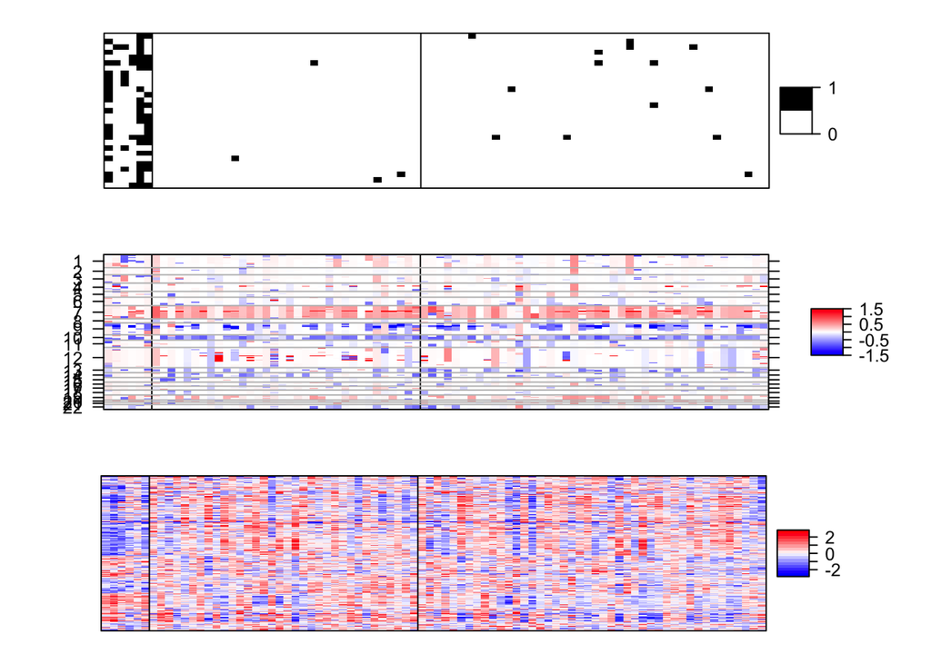

```r
library(magrittr)
# 提取gbm.cn的染色体位置信息
chr <- unlist(strsplit(colnames(gbm.cn), '\\.')) %>%
  extract(seq(1,length(.),by=2)) %>%
  gsub("chr","",.) %>%
  as.numeric()
# 为了更好的展示对过高的值调整
cn.image <- gbm.cn
cn.image[cn.image > 1.5] <- 1.5
cn.image[cn.image < -1.5] <- -1.5
exp.image <- gbm.exp
exp.image[exp.image > 2.5] <- 2.5
exp.image[exp.image < -2.5] <- -2.5
# 选择配色
bw.col <-  colorpanel(2,low="white",high="black")
col.scheme = alist()
col.scheme[[1]] <-  bw.col
col.scheme[[2]] <-  bluered(256)
col.scheme[[3]] <-  bluered(256)
# 作图
plotHeatmap(fit=fit.single,datasets=list(gbm.mut2,cn.image,exp.image),
            type=c("binomial","gaussian","gaussian"),
            col.scheme = col.scheme,
            row.order=c(F,F,T),chr=chr,plot.chr=c(F,T,F),
            sparse=c(T,F,T),cap=c(F,T,F))
```

#### 高级部分

**参数选择**: 上面的`iClusterPlus`设置的K和lambda其实需要很多次调整。要用到`tune.iClusterPlus`对K值进行多次遍历, 之后从中选择最优K值和lamda值。

如下分析推荐用Linux服务器进行, 否则速度会比较慢(Windows用户的cpus只能为1),具体时间视数据量大小而定

> 如下面的代码就跑了差不多10个小时, 平均每个循环2小时, Rdata已经保存。

```r
set.seed(123) # 随机数种子保证每次结果一致性
before_run <- Sys.Date()
for(k in 1:5){
  file_name <- paste("cv.fit.k",k,".Rdata",sep="")
  if ( ! file.exists(file_name)){
    cv.fit  <-  tune.iClusterPlus(cpus=15,dt1=gbm.mut2,dt2=gbm.cn,dt3=gbm.exp,
                      type=c("binomial","gaussian","gaussian"),
                      K=k,n.lambda=185,
                      scale.lambda=c(1,1,1),maxiter=20)
    save(cv.fit, file=file_name) #保存到Rdata文件里，便于中断后继续
}
}
after_run <- Sys.Date()
paste0("Running time is ", after_run-before_run)
```

```
## [1] "Running time is 0"
```

这里的“K1=5”是主要的遍历参数, 而lambda根据使用数据集数目选择, 参考下表. 当然实在不会选就用`lambda=NULL`用默认值。

```r
x1 <- c(1,2,3,4)
x2 <- c("任意选择",
        "8, 13, 21, 34, 55, 89, 144, 233, 377, 610",
        "35, 101, 135, 185, 266, 418, 579, 828, 1010",
        "307, 526, 701, 1019, 2129, 3001, 4001, 5003, 6007")
df <- data.frame(x1 = x1, x2=x2)
colnames(df) <- c("数据类型种类","lambda选择值")
knitr::kable(df, format = "html")
```

| 数据类型种类 | lambda选择值 |
| --- | --- |
| 1 | 任意选择 |
| 2 | 8, 13, 21, 34, 55, 89, 144, 233, 377, 610 |
| 3 | 35, 101, 135, 185, 266, 418, 579, 828, 1010 |
| 4 | 307, 526, 701, 1019, 2129, 3001, 4001, 5003, 6007 |

遍历完成之后, 就可以从结果中选择合适的参数。

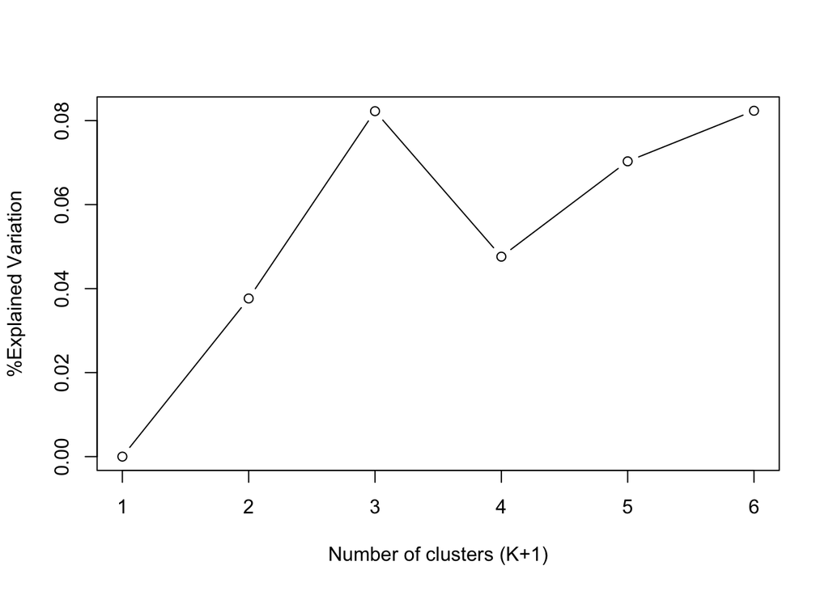

```r
#读取保存的Rdata
output <- alist() # alist里的参数惰性求值
files <- grep("cv.fit",dir())
for(i in 1:length(files)){
    load(dir()[files[i]])
    output[[i]] <- cv.fit
}
# 提取之前设置的K和Lambda
nLambda <-  nrow(output[[1]]$lambda)
nK <-  length(output)
# 获取每个拟合结果中的BIC值
BIC <-  getBIC(output)
# 获取每个拟合结果中的
devR <-  getDevR(output)
# 寻找每个K中最小BIC对应lambda ID
minBICid  <-  apply(BIC,2,which.min)
# 计算最小BIC的
devRatMinBIC <-  rep(NA,nK)
for(i in 1:nK){
    devRatMinBIC[i] <-  devR[minBICid[i],i]
}
plot(1:(nK+1),c(0,devRatMinBIC),
     type="b",
     xlab="Number of clusters (K+1)",
     ylab="%Explained Variation")
```

我们主要根据偏差率(deviance ratio)选择最优K, 计算方式不是重点, 重点是作图后下图里第一个到顶对应的K. (上图K+1=3,所以K=2)。

根据上图结果，从多次遍历中提取最优的聚类和拟合

```r
clusters <- getClusters(output)
rownames(clusters) <- rownames(gbm.exp)
colnames(clusters) <- paste("K=",2:(length(output)+1),sep="")
head(clusters)
```

```
##              K=2 K=3 K=4 K=5 K=6
## TCGA.02.0001   1   3   2   2   1
## TCGA.02.0003   2   3   3   5   3
## TCGA.02.0006   1   3   4   5   3
## TCGA.02.0007   2   3   1   1   6
## TCGA.02.0009   2   1   3   4   4
## TCGA.02.0010   2   2   1   1   5
```

```r
#保存clusters到文件
#write.table(clusters, file="output_clusterMembership.txt",sep='\t',quote=F)
```

`output_clusterMembership.txt`文件作为第一个输出文件，选一列分类，作为画热图时的sample分组信息。

```r
k <- 2
best.cluster <- clusters[,k]
best.fit <- output[[k]]$fit[[which.min(BIC[,k])]]
```

**特征选择**: 对上面找到的3个聚类(K=2)，可以根据lassso系数估计选择最高的几个特征

```r
features <-  alist()
features[[1]] <-  colnames(gbm.mut2)
features[[2]] <-  colnames(gbm.cn)
features[[3]] <-  colnames(gbm.exp)
sigfeatures=alist()
for(i in 1:3){
    rowsum <- apply(abs(best.fit$beta[[i]]),1, sum)
    upper <- quantile(rowsum,prob=0.75)
    sigfeatures[[i]] <- (features[[i]])[which(rowsum>upper)]
}
names(sigfeatures) <- c("mutation","copy number","expression")
#输出每个数据集的前几个特征
head(sigfeatures[[1]])
```

```
## character(0)
```

```r
head(sigfeatures[[2]])
```

```
## [1] "chr1.202692537-202801982" "chr4.52383858-52395837"
## [3] "chr4.52395837-52522387"   "chr4.52522387-52989049"
## [5] "chr4.52989049-53002654"   "chr4.53002654-53517879"
```

```r
head(sigfeatures[[3]])
```

```
## [1] "FSTL1"    "CXCR4"    "MMP7"     "ZEB1"     "KIAA1199" "SERPINF1"
```

如果你发现某一个数据集没有显著的特征，那你就需要调整“高级分析”第一段`tune.iClusterPlus`函数中的`scale.lambda`, 比如说设置成`c(0.05,1,1)`然后重新跑。

**热图展示**: 基于最优拟合画热图

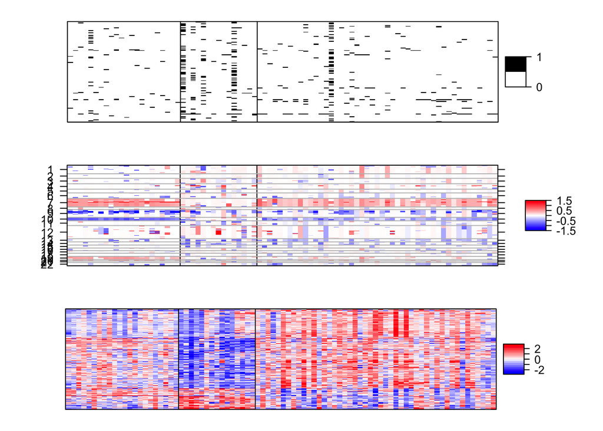

```r
library(magrittr)
# 提取gbm.cn的染色体位置信息
chr <- unlist(strsplit(colnames(gbm.cn), '\\.')) %>%
  extract(seq(1,length(.),by=2)) %>%
  gsub("chr","",.) %>%
  as.numeric()
# 为了更好的展示对过高的值调整
cn.image <- gbm.cn
cn.image[cn.image > 1.5] <- 1.5
cn.image[cn.image < -1.5] <- -1.5
exp.image <- gbm.exp
exp.image[exp.image > 2.5] <- 2.5
exp.image[exp.image < -2.5] <- -2.5

# 选择配色
bw.col <-  colorpanel(2,low="white",high="black")
col.scheme = alist()
col.scheme[[1]] <-  bw.col
col.scheme[[2]] <-  bluered(256)
col.scheme[[3]] <-  bluered(256)
# 作图
plotHeatmap(fit=best.fit,datasets=list(gbm.mut2,cn.image,exp.image),
            type=c("binomial","gaussian","gaussian"),
            col.scheme = col.scheme,
            row.order=c(F,F,T),chr=chr,plot.chr=c(F,T,F),
            sparse=c(T,F,T),cap=c(F,T,F))
```

### 输出文件

把clusters、特征基因和值保存到文件，就可以用自己的heatmap代码画热图了。

```r
write.table(clusters, file="output_clusterMembership.txt",sep='\t',quote=F)

write.csv(t(gbm.mut2),"output_mut2.csv",quote = F)
write.csv(t(cn.image),"output_cn.csv",quote = F)
write.csv(t(exp.image),"output_exp.csv",quote = F)
```